# STAT5003

Week 4: Q & A

Dr. Justin Wishart

Semester 2, 2020

## k-means algorithm

- What are $m$, $\widehat{\overline{x}_k}$ and $\widehat{\overline{x}_j}$
1. Find cluster means with cluster memberships fixed
   $$\begin{align*}
   \widehat{\overline{x}_j} = \text{argmin}_m \sum_{cluster(i) = j} ||x_i - m||^2
   \end{align*}$$
2. Find cluster memberships with cluster means fixed
   $$\begin{align*}
   \widehat{cluster(i)} = \text{argmin}_k ||x_i - \widehat{\overline{x}_k}||^2
   \end{align*}$$

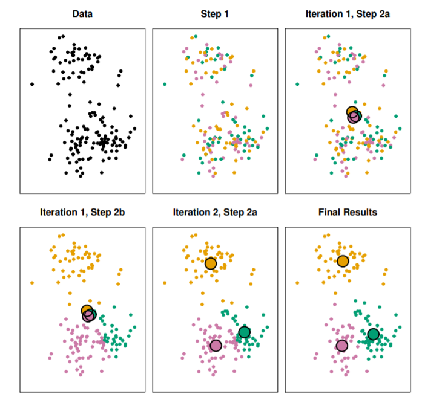

## Variance of Sum

- For any constants $a, b$
  $$\begin{align}
  Var(aX + bY) = a^2 Var(X) + b^2 Var(Y) + 2abCov(X,Y)
  \end{align}$$
  . but in the lecture slide there is no multiplier of 2

$$\begin{align*}
\mathbb{V}\text{ar}(Z_1) = \mathbb{V}\text{ar}( \boldsymbol{\phi}_1^T \boldsymbol{X}) = \sum_{i = 1}^p \phi_{i1}^2 \mathbb{V}\text{ar}(X_i) + \sum_{i \neq j}\phi_{i1}\phi_{j1}\mathbb{C}\text{ov}(X_i, C_j)
\end{align*}$$

$$\begin{align*}
\boldsymbol{\Sigma} = \mathbb{V}\text{ar}(\boldsymbol{X}) =
\begin{pmatrix}
\mathbb{V}\text{ar}(X_1) & \mathbb{C}\text{ov}(X_1, X_2)\\
\mathbb{C}\text{ov}(X_1, X_2) & \mathbb{V}\text{ar}(X_2)
\end{pmatrix}
\end{align*}$$

All terms get added. The off diagonal terms appear twice since matrix is symmetric

## Why doesn’t k-means work well when cluster sizes are different?

- Recall
  $$\begin{align*}
  \widehat{\overline{x}_j} = \text{argmin}_m \sum_{cluster(i) = j} ||x_i - m||^2
  \end{align*}$$
  2. Find cluster memberships with cluster means fixed
     $$\begin{align*}
     \widehat{cluster(i)} = \text{argmin}_k ||x_i - \widehat{\overline{x}_k}||^2
     \end{align*}$$
- It assumes the nearest cluster mean is the best one to assign.

## $k$-means good for spherical distributions

- Recall
  $$\begin{align*}
  \widehat{\overline{x}_j} = \text{argmin}_m \sum_{cluster(i) = j} ||x_i - m||^2
  \end{align*}$$
  2. Find cluster memberships with cluster means fixed
     $$\begin{align*}
     \widehat{cluster(i)} = \text{argmin}_k ||x_i - \widehat{\overline{x}_k}||^2
     \end{align*}$$
- The membership is assigned to the Euclidean distance
  - If the data has spherical clusters, it aligns with the modelling.

## SVD vs PCA (Not assessable)

- SVD is one of the fundamental matrix factorizations
  - Use pen for this.

## PCA parameters

- Are there any parameters to tweak here?
- PCA: No but there are choices in scaling or other PCA variants.
  - If uncentered: Lose the maximizing variance interpretation
  - If not scaling: Features with large scales contribute more to the variance.
- Sparse PCA: Can use when $p$ much bigger than $n$
  - Add sparsity penalty
- Functional PCA: Vary over time and space
- Robust PCA: Use the different metric
  - Squares metric (Variance based of sum of squares) can be sensitive to single points
  - Use a different metric, such as absolute value

## MDS parameters

- Are there any parameters to tweak here?
- Can choose different stress function
  - Takes distance matrix gives output projections
- Least squares or Kruskal-Shephard Scaling:
  $$\begin{align}
  \sqrt{\sum_{i \neq j}(d_{ij} - ||z_i - z_{j}||)^2}
  \end{align}$$
  - Used in `cmdscale`
- Sammon mapping: normalizes for smaller distances
  $$\begin{align}
  \sqrt{\sum_{i \neq j}(\frac{d_{ij} - ||z_i - z_{j}||}{d_{ij}})^2}
  \end{align}$$
  - See `MASS::sammon`
- Shepard-Kruskal nonmetric scaling:
  $$\begin{align}
  \sqrt{\sum_{i \neq j}(d_{ij} - g(||z_i - z_{j}||))^2}
  \end{align}$$
  - Where some $g$ is an increasing function.
  - See `isoMDS` (think it uses a power transform here $g(x) = x^q$, $q\ge 1$)

## Biplot interpretation

- PCs are given on one set of axes (for all original data points)
- “Loadings” (up to the scale argument) are given on other set of axes
- Arrow gives linear weightings for that variable in PC space
  - Pointing in same direction indicates variables are positively correlated.
  - Opposite directions indicate negative correlation
  - Perpendicular indicate zero correlation.

## Reference list

```
## You haven't cited any references in this bibliography yet.
```

NULL